# Two-Way ANOVA Analysis

Methods for performing a complete Two-Way ANOVA.

# Model Fitting in R

In this module, a thorough Two-Way ANOVA will be performed using the experiment inroduced in the previous module, where the effect of tadpole density and UV-B light intensity on tadpole body mass was examined. These are loaded into R below. Because `density` was recorded as a number (i.e., 1, 2, and 4) rather than as an obvious grouping (i.e., “one”, “two”, and “four”), it must be explicitly converted to a factor before using.

```
tad <- read.csv("http://derekogle.com/NCMTH207/modules/readings/data/Tadpoles.csv")
tad$density <- factor(tad$density)
str(tad)
```

```
#R>   'data.frame': 90 obs. of  3 variables:
#R>    $ uvb    : chr  "High" "High" "High" "High" ...
#R>    $ density: Factor w/ 3 levels "1","2","4": 1 1 1 1 1 1 1 1 1 1 ...
#R>    $ mass   : num  0.91 0.65 1.58 0.98 1.07 0.84 0.88 1.47 0.94 0.72 ...
```

When fitting a linear model in R the first argument to `lm()` must be a formula of the form `response~factorA+factorB+factorA:factorB`[^1] where `response` is the response variables, `factorA` and `factorB` are the two factor variables, and `factorA:factorB` tells `lm()` to include the interaction between the two factor variables. Thus, the Two-Way ANOVA model for the tadpole experiment is fit as follows.

```
lm1 <- lm(mass~density+uvb+density:uvb,data=tad)
```

As usual, the results are saved to an object for checking assumptions, creating an ANOVA table, and making multiple comparisons.

# Assumptions

The assumptions for a Two-Way ANOVA are exactly the same as for a One-Way ANOVA as shown in a previous module. Thus, assumptions are checked in R in the exact same manner as described in that module (i.e., using `assumptionCheck()`).

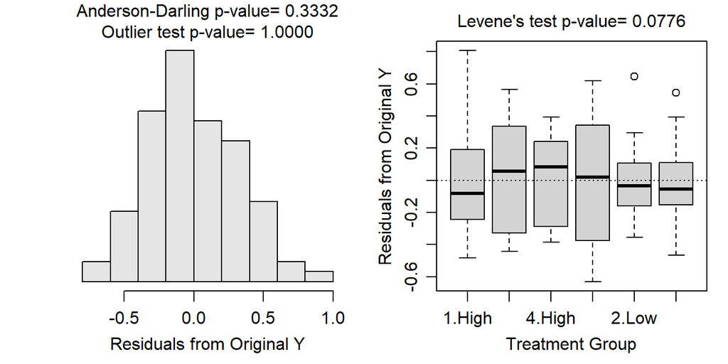

```
assumptionCheck(lm1)
```

# Main and Interaction Effects (ANOVA Table)

```
aov1 <- anova(lm1)
```

The ANOVA table is extracted from the `lm()` object with `anova()`.

```
anova(lm1)
```

```
#R>   Analysis of Variance Table
#R>
#R>   Response: mass
#R>               Df Sum Sq Mean Sq F value    Pr(>F)
#R>   density      2 2.4337 1.21686 10.3814 9.355e-05
#R>   uvb          1 0.3004 0.30044  2.5632    0.1131
#R>   density:uvb  2 0.2989 0.14947  1.2752    0.2847
#R>   Residuals   84 9.8461 0.11722
```

These results indicate that the interaction effect is insignificant (p=0.2847). Because the interaction term is insignificant, the main effects can be interpreted. The density main effect is strongly significant (p=0.0001), but the UV-B main effect is not significant (p=0.1131). Thus, it appears that the mean body mass of tadpoles differs among some of the density treatments but not between the two UV-B light intensities.

# Multiple Comparisons

### Main Effects

```
mc1 <- emmeans(lm1,specs=pairwise~density)
```

Thus, if the interaction term is not significant then you should fit a new model without the interaction term and then use that model when performing multiple comparisons. A model without an interaction term simply uses a formula of the form `response~factorA+factorB` in `lm()`. The ANOVA table is shown below to confirm that the interaction term is not in this new model.

```
lm1_noint <- lm(mass~density+uvb,data=tad)
anova(lm1_noint)
```

```
#R>   Analysis of Variance Table
#R>
#R>   Response: mass
#R>             Df  Sum Sq Mean Sq F value    Pr(>F)
#R>   density    2  2.4337 1.21686 10.3154 9.649e-05
#R>   uvb        1  0.3004 0.30044  2.5469    0.1142
#R>   Residuals 86 10.1450 0.11797
```

With this the multiple comparisons for a main effect factor variable is performed as described for a One-Way ANOVA in a previous module.

```
mc1_noint <- emmeans(lm1_noint,specs=pairwise~density)
( mc1sum_noint <- summary(mc1_noint,infer=TRUE) )
```

```
#R>   $emmeans
#R>    density emmean     SE df lower.CL upper.CL t.ratio p.value
#R>    1        1.157 0.0627 86    1.033    1.282 18.456  <.0001
#R>    2        0.829 0.0627 86    0.704    0.953 13.215  <.0001
#R>    4        0.791 0.0627 86    0.667    0.916 12.620  <.0001
#R>
#R>   Results are averaged over the levels of: uvb
#R>   Confidence level used: 0.95
#R>
#R>   $contrasts
#R>    contrast estimate     SE df lower.CL upper.CL t.ratio p.value
#R>    1 - 2      0.3287 0.0887 86    0.117    0.540 3.706   0.0011
#R>    1 - 4      0.3660 0.0887 86    0.154    0.578 4.127   0.0002
#R>    2 - 4      0.0373 0.0887 86   -0.174    0.249 0.421   0.9070
#R>
#R>   Results are averaged over the levels of: uvb
#R>   Confidence level used: 0.95
#R>   Conf-level adjustment: tukey method for comparing a family of 3 estimates
#R>   P value adjustment: tukey method for comparing a family of 3 estimates
```

### Interaction Effects

If an interaction effect had been present in the original Two-Way ANOVA model, multiple comparisons must be carried out to determine which pairs of **treatment** means differ. This is easily accomplished with `emmeans()` by using the interaction variable in the `pairwise~` formula. For example, if `lm1` had had a significant interaction term, the multiple comparisons for all pairs of treatments would be computed as follows.

```
mc1 <- emmeans(lm1,specs=pairwise~density:uvb)
( mc1sum <- summary(mc1,infer=TRUE) )
```

```
#R>   $emmeans
#R>    density uvb  emmean     SE df lower.CL upper.CL t.ratio p.value
#R>    1       High  1.023 0.0884 84    0.848    1.199 11.576  <.0001
#R>    2       High  0.784 0.0884 84    0.608    0.960  8.869  <.0001
#R>    4       High  0.797 0.0884 84    0.621    0.972  9.012  <.0001
#R>    1       Low   1.291 0.0884 84    1.116    1.467 14.608  <.0001
#R>    2       Low   0.873 0.0884 84    0.698    1.049  9.879  <.0001
#R>    4       Low   0.786 0.0884 84    0.610    0.962  8.892  <.0001
#R>
#R>   Confidence level used: 0.95
#R>
#R>   $contrasts
#R>    contrast        estimate    SE df lower.CL upper.CL t.ratio p.value
#R>    1 High - 2 High   0.2393 0.125 84  -0.1253   0.6039  1.914  0.4007
#R>    1 High - 4 High   0.2267 0.125 84  -0.1379   0.5913  1.813  0.4631
#R>    1 High - 1 Low   -0.2680 0.125 84  -0.6326   0.0966 -2.144  0.2754
#R>    1 High - 2 Low    0.1500 0.125 84  -0.2146   0.5146  1.200  0.8357
#R>    1 High - 4 Low    0.2373 0.125 84  -0.1273   0.6019  1.898  0.4103
#R>    2 High - 4 High  -0.0127 0.125 84  -0.3773   0.3519 -0.101  1.0000
#R>    2 High - 1 Low   -0.5073 0.125 84  -0.8719  -0.1427 -4.058  0.0015
#R>    2 High - 2 Low   -0.0893 0.125 84  -0.4539   0.2753 -0.715  0.9797
#R>    2 High - 4 Low   -0.0020 0.125 84  -0.3666   0.3626 -0.016  1.0000
#R>    4 High - 1 Low   -0.4947 0.125 84  -0.8593  -0.1301 -3.957  0.0021
#R>    4 High - 2 Low   -0.0767 0.125 84  -0.4413   0.2879 -0.613  0.9898
#R>    4 High - 4 Low    0.0107 0.125 84  -0.3539   0.3753  0.085  1.0000
#R>    1 Low - 2 Low     0.4180 0.125 84   0.0534   0.7826  3.344  0.0152
#R>    1 Low - 4 Low     0.5053 0.125 84   0.1407   0.8699  4.042  0.0016
#R>    2 Low - 4 Low     0.0873 0.125 84  -0.2773   0.4519  0.699  0.9816
#R>
#R>   Confidence level used: 0.95
#R>   Conf-level adjustment: tukey method for comparing a family of 6 estimates
#R>   P value adjustment: tukey method for comparing a family of 6 estimates
```

As before, results for the individual means are in the `$emmeans` portion of the output and the results for differences in paired means are in the `$contrasts` portion.

# Graphing Results

### Interaction Plot

The results of a Two-Way ANOVA are summarizaed in an **interaction plot** whether a significant interaction was present in the results or not. An interaction plot, which was introduced in a previous module, show each treatment mean with the levels of one factor on the x-axis and the levels of other other factor shown with different colors or symbols and sometimes connected with a line. The interaction plot made here will also include a confidence intervals for each treatment mean.

The method shown below requires having saved the summary of the multiple comparisons procedure applied to the **model that included the interaction term.** This was created above and saved as `mc1sum`. The data we want to plot is in the `$emmeans` portion of this object.

```
mc1sum$emmeans
```

```
#R>    density uvb  emmean     SE df lower.CL upper.CL t.ratio p.value
#R>    1       High  1.023 0.0884 84    0.848    1.199 11.576  <.0001
#R>    2       High  0.784 0.0884 84    0.608    0.960  8.869  <.0001
#R>    4       High  0.797 0.0884 84    0.621    0.972  9.012  <.0001
#R>    1       Low   1.291 0.0884 84    1.116    1.467 14.608  <.0001
#R>    2       Low   0.873 0.0884 84    0.698    1.049  9.879  <.0001
#R>    4       Low   0.786 0.0884 84    0.610    0.962  8.892  <.0001
#R>
#R>   Confidence level used: 0.95
```

Specifically, we want to plot the results in the `emmean` column with the confidence intervals in `lower.CL` and `upper.CL` against one of the factor variables. One issue is that the confidence intervals for the multiple treatments defined by one level of the variable on the x-axis will overlap. Thus, before plotting we define a “dodge” amount with `position_dodge()` that will shift the levels of the other factor slightly left and right to eliminate the overlap. The `width=` argument defines the amount of shift. You may need to “play” with this value to get the exact look that you want.

```
pd <- position_dodge(width=0.1)
```

The summary graphic is constucted with the code below. This code is similar to what was used for the summary graphic of a One-Way ANOVA. However, in this code, note

- the use of `mc1sum$emmeans` as the data,
- the use of `density` (i.e., one of the factor variables) as `x=`,
- the use of `uvb` (i.e., the other factor variale) in `group=` (so it will be “dodged”) and `color=` (so it will be denoted with different colors),
- that `geom_line()` is placed first so that the points and confidence intervals will be on top of the connecting lines,
- that `alpha=` is used in `geom_line()` so that the lines are subtle, and
- the use of `pd` from `position_dodge()` above in `geom_pointrange()`.

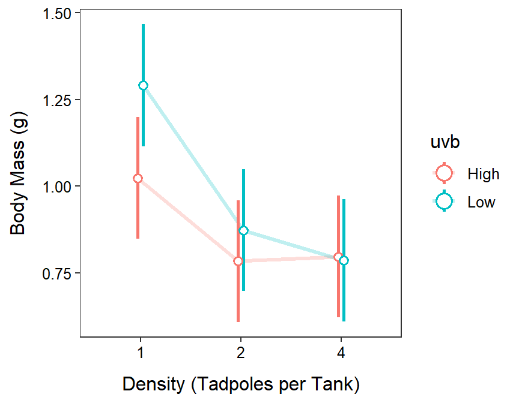

```
ggplot(data=mc1sum$emmeans,mapping=aes(x=density,group=uvb,color=uvb,
                                       y=emmean,ymin=lower.CL,ymax=upper.CL)) +
  geom_line(position=pd,size=1.1,alpha=0.25) +
  geom_pointrange(position=pd,size=1,fatten=2,pch=21,fill="white") +
  labs(y="Body Mass (g)",x="Density (Tadpoles per Tank)") +
  theme_NCStats()
```

### Main Effects Plot

Some researchers prefer to plot just the main effects when there is no significant interaction effect in the data. Such a plot is called a **main effects** plot and can be constructed similarly from the multiple comparison results using the model without an interaction term. Note that `group=1` must be used as shown below so that `geom_line()` will work properly.

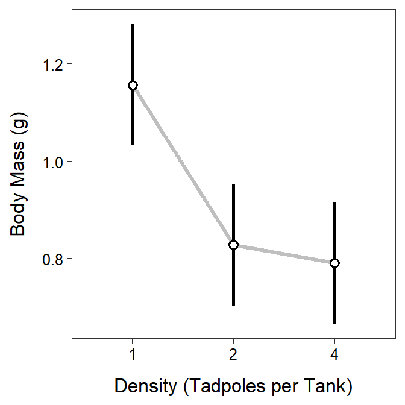

```
ggplot(data=mc1sum_noint$emmeans,mapping=aes(x=density,group=1,
                                       y=emmean,ymin=lower.CL,ymax=upper.CL)) +
  geom_line(size=1.1,alpha=0.25) +
  geom_pointrange(size=1,fatten=2,pch=21,fill="white") +
  labs(y="Body Mass (g)",x="Density (Tadpoles per Tank)") +
  theme_NCStats()
```

# Corrections

If you see any errors (code, typographical, or logical) please bring these to my attention.

# Reuse

Text and figures are licensed under Creative Commons Attribution [CC BY-SA 4.0](https://creativecommons.org/licenses/by-sa/4.0/). Items reused from other places are noted as such.

[^1]: This exact model may also be entered with the shorthand `response~factorA*factorB`.